# Applied Research: Descriptive with R

Carlos Utrilla Guerrero

5/13/2020

# WELCOME

Welcome to the workshop number 2: Introduction to stats with R.

## Learning outcomes

By the end of this assignment(s), you should be able to: • Read in your own data with different methods. • Clean and manipulate your data with R functions. • Explore your data with summary statistics. • Create graphs for exploring your data. • Apply what you have learned to your/other data

## Dataset

In this assignment(s), we will use the following dataset:

1. `Workshop Statistics_ descriptives .xlsx`.

## Download the dataset

For this session, make sure to download and save the datasets in `.xlsx`. Please save the Excel file in a folder that you will use for this practical (e.g. `workshop/data/`).

### Setup your working directory

Once you have your dataset saved in Excel, you still need to set your working directory in R.

To do this, try to find out first where your working directory is set at this moment:

```r
getwd()
```

```
## [1] "C:/Users/P70069673/Documents/Github/AppliedRR/AppliedRR/inputs"
```

By executing this command, R now knows exactly in which folder you’re working. Ideally, the output of this code is the location of your Excel file.

### Read into R

We can do it in two main ways:

- 1. Basic R commands using `readxl` package

This is a package that you can use to load in Excel files in R. You will need to install the package as following:

```r
#install.packages("readxl")
library(readxl)
```

```r
getwd()
```

```
## [1] "C:/Users/P70069673/Documents/Github/AppliedRR/AppliedRR/inputs"
```

```r
mydat1 <- read_xlsx('../data/Workshop Statistics_ descriptives .xlsx')
```

- 2. Using graphical user interface

It might be also an option for you to get help of R studio, with no code at all. For this propose, you can go to:

`file -> import Dataset -> excel -> _select your file_ -> import`

Nevertheless, we have another way to read the file directly from google sheet. It doesn’t need to be downloaded the file since it imports into R. If you want to learn more about it, here is one way:

- Install `gsheet` package:

```r
#install.packages("gsheet")
library(gsheet)
```

- Copy and paste the url of the google docs. Then Create a object `url` to store the information

```r
url <- 'https://docs.google.com/spreadsheets/d/1JchKI5u-I5IcWbnM_JpMkMJIZX1012oJVoIEZz2ra3c/edit#gid=0'
```

```r
mydat <- gsheet2tbl(url)
```

```r
library(dplyr)
```

```r
library(ggplot2)
```

## Understanding a data frame

First thing first, we need to make sure that we correctly imported the dataset. Use the `View()` to look the entire dataframe in new windows.

```r
View(mydat)
```

Use the code `print()` to print the entire dataframe in the console

```r
print(mydat) # printing all dataset with NA
```

```
## # A tibble: 69 x 8
##    group tutor  year   age length `favourite pet:~ `do you like ga~
##    <dbl> <chr> <dbl> <dbl>  <dbl>            <dbl>            <dbl>
##  1     1 unkn~  2019    19    171                2              -99
##  2     1 unkn~  2019    23    173                2                8
##  3     1 unkn~  2019    24    165                2              -99
##  4     2 unkn~  2019    18    170                2              -99
##  5     2 unkn~  2019    20    160                2                7
##  6     2 unkn~  2019    26    170                2                8
##  7     2 unkn~  2019    27    180                2              -99
##  8     2 unkn~  2019    33    182                2              -99
##  9     3 unkn~  2019    18    157                1              -99
## 10     3 unkn~  2019    19    153                1                3
## # ... with 59 more rows, and 1 more variable: `do you like Lord of the Rings:
## #   1(not at all) - 10 (best thing in the world)` <dbl>
```

Use the code `head()` and `tail()` to print top and bottom dataframe respectively.

```r
head(mydat)
```

| group | tutor | year | age | length | favourite pet: cat(= 1) or dog (=2) | do you like game of Thrones: 1(not at all)-10(best thing in the world) | do you like Lord of the Rings: 1(not at all) - 10 (best thing in the world) |
| --- | --- | --- | --- | --- | --- | --- | --- |
| 1 | unknown | 2019 | 19 | 171 | 2 | -99 | 6 |
| 1 | unknown | 2019 | 23 | 173 | 2 | 8 | 7 |
| 1 | unknown | 2019 | 24 | 165 | 2 | -99 | 1 |
| 2 | unknown | 2019 | 18 | 170 | 2 | -99 | -99 |
| 2 | unknown | 2019 | 20 | 160 | 2 | 7 | -99 |
| 2 | unknown | 2019 | 26 | 170 | 2 | 8 | 7 |

```r
tail(mydat,5) # last five observations
```

| group | tutor | year | age | length | favourite pet: cat(= 1) or dog (=2) | do you like game of Thrones: 1(not at all)-10(best thing in the world) | do you like Lord of the Rings: 1(not at all) - 10 (best thing in the world) |
| --- | --- | --- | --- | --- | --- | --- | --- |
| 7 | Hidde | 2020 | 20 | 165 | 2 | -99 | 4 |
| 7 | Hidde | 2020 | 28 | 157 | 2 | 7 | -99 |
| 0 | PEERS | 2020 | 23 | 169 | 2 | 6 | 4 |
| 0 | PEERS | 2020 | 20 | 159 | 1 | 7 | 4 |
| 0 | PEERS | 2020 | 22 | 169 | 2 | -99 | -99 |

It is time to make our first diagnostic of the dataset. We can receive a reasonably set of information per variable running the following code:

```r
str(mydat)
```

```
## tibble [69 x 8] (S3: spec_tbl_df/tbl_df/tbl/data.frame)
##  $ group                                                                      : num [1:69] 1 1 1 2 2 2 2 2 3 3 ...
##  $ tutor                                                                      : chr [1:69] "unknown" "unknown" "unknown" "unknown" ...
##  $ year                                                                       : num [1:69] 2019 2019 2019 2019 2019 ...
##  $ age                                                                        : num [1:69] 19 23 24 18 20 26 27 33 18 19 ...
##  $ length                                                                     : num [1:69] 171 173 165 170 160 170 180 182 157 153 ...
##  $ favourite pet: cat(= 1) or dog (=2)                                        : num [1:69] 2 2 2 2 2 2 2 2 1 1 ...
##  $ do you like game of Thrones: 1(not at all)-10(best thing in the world)     : num [1:69] -99 8 -99 -99 7 8 -99 -99 -99 3 ...
##  $ do you like Lord of the Rings: 1(not at all) - 10 (best thing in the world): num [1:69] 6 7 1 -99 -99 7 8 9 -99 1 ...
##  - attr(*, "spec")=
##   .. cols(
##   ..   group = col_double(),
##   ..   tutor = col_character(),
##   ..   year = col_double(),
##   ..   age = col_double(),
##   ..   length = col_double(),
##   ..   `favourite pet: cat(= 1) or dog (=2)` = col_double(),
##   ..   `do you like game of Thrones: 1(not at all)-10(best thing in the world)` = col_double(),
##   ..   `do you like Lord of the Rings: 1(not at all) - 10 (best thing in the world)` = col_double()
##   .. )
```

Alrighty, the data contains 69 observations and 8 different variables. We can also observe that all variables are considered as `numeric (num)` except tutor variable which is character or text `char`. Before starting to make further data exploration, we need to highlight some remarkable data quality inconsistencies.

- Firstly, the name of the variables are very large and it requires to be re-named if we want to make this dataset ready and more convenient for further data explorations.
- We can notice that the amount of empty responses and/or -99 are considerably high. We need to consistently assign missing values to empty responses and -99 in a way that R can read it.
- Some variables are not in the right format, for instance `favourite pet` as considering `numeric`instead of `categorical`. Indeed, it might be worth to convert this variable into a dummy one.

It is therefore necessary to wrangle the data, and clean it a little bit! We will do this in the next section ‘Data cleaning’, which consists of three sub-sections.

## Data cleaning

Perform some modification to the dataset in order to tune it and get ready for further data analysis.

*N.B.*: It is a good practice to always save the original dataset before starting to make further steps. Please type the following:

```r
mydat_original <- mydat
print(mydat1)
```

```
## # A tibble: 74 x 8
##    group tutor  year   age length `favourite pet:~ `do you like ga~
##    <dbl> <chr> <dbl> <dbl>  <dbl>            <dbl>            <dbl>
##  1     1 unkn~  2019    19    171                2              -99
##  2     1 unkn~  2019    23    173                2                8
##  3     1 unkn~  2019    24    165                2              -99
##  4     2 unkn~  2019    18    170                2              -99
##  5     2 unkn~  2019    20    160                2                7
##  6     2 unkn~  2019    26    170                2                8
##  7     2 unkn~  2019    27    180                2              -99
##  8     2 unkn~  2019    33    182                2              -99
##  9     3 unkn~  2019    18    157                1              -99
## 10     3 unkn~  2019    19    153                1                3
## # ... with 64 more rows, and 1 more variable: `do you like Lord of the Rings:
## #   1(not at all) - 10 (best thing in the world)` <dbl>
```

```r
# look at the structure of your data
str(mydat)
```

```
## tibble [69 x 8] (S3: spec_tbl_df/tbl_df/tbl/data.frame)
##  $ group                                                                      : num [1:69] 1 1 1 2 2 2 2 2 3 3 ...
##  $ tutor                                                                      : chr [1:69] "unknown" "unknown" "unknown" "unknown" ...
##  $ year                                                                       : num [1:69] 2019 2019 2019 2019 2019 ...
##  $ age                                                                        : num [1:69] 19 23 24 18 20 26 27 33 18 19 ...
##  $ length                                                                     : num [1:69] 171 173 165 170 160 170 180 182 157 153 ...
##  $ favourite pet: cat(= 1) or dog (=2)                                        : num [1:69] 2 2 2 2 2 2 2 2 1 1 ...
##  $ do you like game of Thrones: 1(not at all)-10(best thing in the world)     : num [1:69] -99 8 -99 -99 7 8 -99 -99 -99 3 ...
##  $ do you like Lord of the Rings: 1(not at all) - 10 (best thing in the world): num [1:69] 6 7 1 -99 -99 7 8 9 -99 1 ...
##  - attr(*, "spec")=
##   .. cols(
##   ..   group = col_double(),
##   ..   tutor = col_character(),
##   ..   year = col_double(),
##   ..   age = col_double(),
##   ..   length = col_double(),
##   ..   `favourite pet: cat(= 1) or dog (=2)` = col_double(),
##   ..   `do you like game of Thrones: 1(not at all)-10(best thing in the world)` = col_double(),
##   ..   `do you like Lord of the Rings: 1(not at all) - 10 (best thing in the world)` = col_double()
##   .. )
```

### Change column names

Firstly, diplay the column names with `names()` function:

```r
names(mydat)
```

```
## [1] "group"
## [2] "tutor"
## [3] "year"
## [4] "age"
## [5] "length"
## [6] "favourite pet: cat(= 1) or dog (=2)"
## [7] "do you like game of Thrones: 1(not at all)-10(best thing in the world)"
## [8] "do you like Lord of the Rings: 1(not at all) - 10 (best thing in the world)"
```

Last three columns are inconveniently named. Using names() with indicating the specific position will change the name of these columns. Be sure to select properly the elements of the vector.

For instance, rename column 6 to favPet. The command will be as following:

```r
# change the name col 6
names(mydat)[6] <- "favPet"
```

Do you want to change the name of more than one column at the same time? Use the following command to replace the last two column names to `GoT` and `LotR`, respectively.

```r
names(mydat)[7:8] <- c('GoT','LotR')
```

#### Exercise 1: Check/list the variable names in our data set. Have the variable names of column 6 through 8 been successfully changed?

```r
names(mydat) # yes
```

```
## [1] "group"  "tutor"  "year"   "age"    "length" "favPet" "GoT"    "LotR"
```

### Missing data

Dataframes/ datasets are not always complete. Consequently, we have to deal with missing values. You have to identify values as missing if your dataframe isn’t complete because you do not want them to be included in your analysis. In the current dataframe (mydat), missings have been coded as -99 (which is usually the code given to a “missing value”). In R, we need to convert all these records to NA.

```r
mydat$GoT[mydat$GoT == -99] <- NA
mydat$LotR[mydat$LotR == -99] <- NA
```

Check one of the variable if it represents a missing value

```r
is.na(mydat$GoT) # Check one of the variable if it represents a missing value
```

```
##  [1]  TRUE FALSE  TRUE  TRUE FALSE FALSE  TRUE  TRUE  TRUE FALSE  TRUE FALSE
## [13] FALSE FALSE FALSE  TRUE  TRUE FALSE FALSE FALSE  TRUE FALSE  TRUE  TRUE
## [25]  TRUE  TRUE  TRUE  TRUE FALSE  TRUE FALSE  TRUE FALSE FALSE  TRUE FALSE
## [37]  TRUE FALSE  TRUE  TRUE FALSE  TRUE FALSE FALSE FALSE FALSE  TRUE  TRUE
## [49] FALSE FALSE FALSE FALSE FALSE FALSE  TRUE  TRUE FALSE  TRUE FALSE FALSE
## [61]  TRUE  TRUE FALSE FALSE  TRUE FALSE FALSE FALSE  TRUE
```

Check again, first 6 rows of the data set

```r
head(mydat,6)
```

| group | tutor | year | age | length | favPet | GoT | LotR |
| --- | --- | --- | --- | --- | --- | --- | --- |
| 1 | unknown | 2019 | 19 | 171 | 2 | NA | 6 |
| 1 | unknown | 2019 | 23 | 173 | 2 | 8 | 7 |
| 1 | unknown | 2019 | 24 | 165 | 2 | NA | 1 |
| 2 | unknown | 2019 | 18 | 170 | 2 | NA | NA |
| 2 | unknown | 2019 | 20 | 160 | 2 | 7 | NA |
| 2 | unknown | 2019 | 26 | 170 | 2 | 8 | 7 |

It looks like we still have missing values within the variables age, length and favPet. They still have to be identified as such, let’s do that right now!

#### Exercise 2: The following variables also contain missing data (-99): age, length and favPet. Could you convert all these records into NA?

```r
mydat$age[mydat$age == -99] <- NA
mydat$length[mydat$length == -99] <- NA
mydat[mydat == -99] <- NA
```

Next to changing -99 to NA per variable, it can be changed for all variables in an entire data set. The precondition is that -99 represents in all variables a missing data point! This was the case in the current data set, so we could have also chosen to change it for all variables at once by giving the command: `mydat[mydat == -99] <- NA`

### Dummy variables:

Dummy variables (or binary variables) are a specific type of categorical variable. They have only two values (0 = an event hasn’t occurred; 1 = an event occurred). Dummy variables are commonly used in statistical analyses and in more simple descriptive statistics. A dummy column is one which has a value of one when a categorical event occurs and a zero when it doesn’t occur. Indeed, we want to modify the variable favPet to a dummy variable. Specifically, we want the variable favPet to say whether we have seen a dog (=1) or not (=0; thus a cat). In this case, value 0 takes when is ‘cat’. Otherwise value 1. Here you can see how to convert the value 1 for cat to value 0 when it is a cat.

```r
# check my data
str(mydat)
```

```
## tibble [69 x 8] (S3: spec_tbl_df/tbl_df/tbl/data.frame)
##  $ group : num [1:69] 1 1 1 2 2 2 2 2 3 3 ...
##  $ tutor : chr [1:69] "unknown" "unknown" "unknown" "unknown" ...
##  $ year  : num [1:69] 2019 2019 2019 2019 2019 ...
##  $ age   : num [1:69] 19 23 24 18 20 26 27 33 18 19 ...
##  $ length: num [1:69] 171 173 165 170 160 170 180 182 157 153 ...
##  $ favPet: num [1:69] 2 2 2 2 2 2 2 2 1 1 ...
##  $ GoT   : num [1:69] NA 8 NA NA 7 8 NA NA NA 3 ...
##  $ LotR  : num [1:69] 6 7 1 NA NA 7 8 9 NA 1 ...
##  - attr(*, "spec")=
##   .. cols(
##   ..   group = col_double(),
##   ..   tutor = col_character(),
##   ..   year = col_double(),
##   ..   age = col_double(),
##   ..   length = col_double(),
##   ..   `favourite pet: cat(= 1) or dog (=2)` = col_double(),
##   ..   `do you like game of Thrones: 1(not at all)-10(best thing in the world)` = col_double(),
##   ..   `do you like Lord of the Rings: 1(not at all) - 10 (best thing in the world)` = col_double()
##   .. )
```

#### Exercise 3: Can you convert `favPet` outcome to 1 when is a `dog (=2)`?

```r
mydat$favPet[mydat$favPet==1] <- 0
mydat$favPet[mydat$favPet==2] <- 1
```

Please, always check the new modifications out in the console.

#### Exercise 4: Can you please return the last 10 records of `mydat`?

Forgot how? Check out exploration of data again.

```r
# show an example 10 recods
tail(mydat$favPet,10)
```

```
##  [1] 1 1 1 1 0 1 1 1 0 1
```

#### Exercise 5: Can you please return the first 15 records of the column `favPet` from `mydat`? You should see a set of 1 and 0 values.

```r
head(mydat$favPet,15)
```

```
##  [1] 1 1 1 1 1 1 1 1 0 0 1 1 1 0 1
```

### Factor Variable

Factors are used to store categorical data. They are important for statistical modeling (analysis), since categorical variables are treated differently in statistical models than continous variables. This ensures categorical data is treated accordignly in our statistical analysis and data visualisation. Factors are the data objects which are used to categorize the data and store it as labels. It seems like we need also `favPet` to be treated as a `factor` since we might be interested in making some graphs at a later stage.

Now we can check if the variable `favPet` is a factor variable.

```r
# check if factor
is.factor(mydat$favPet)
```

```
## [1] FALSE
```

Well, it returns FALSE. Indeed, we have seen before that `favPet` is a numeric. The most common numeric types in R are integrers and doubles. You can explore which type of numeric type with`typeof()`

```r
class(mydat$favPet)
```

```
## [1] "numeric"
```

Now it is time to convert it into a `factor` variable. The first label ‘cat’, will correspond to favPet=0 and the second label ‘dog’, will correspond to favPet=1 because the order of the labels will follow the numeric order of the data (which in this case is 0, 1).

```r
mydat$favPet <- factor(mydat$favPet, labels = c('cat','dog'))
```

We can check our new modifications now:

```r
str(mydat$favPet)
```

```
##  Factor w/ 2 levels "cat","dog": 2 2 2 2 2 2 2 2 1 1 ...
```

```r
# select variable favPet using $
mydat$favPet
```

```
##  [1] dog  dog  dog  dog  dog  dog  dog  dog  cat  cat  dog  dog  dog  cat  dog
## [16] dog  cat  cat  cat  cat  dog  dog  dog  cat  dog  dog  dog  dog  cat  cat
## [31] dog  cat  dog  dog  dog  dog  dog  dog  cat  dog  dog  dog  dog  dog  cat
## [46] cat  cat  cat  dog  dog  cat  dog  dog  dog  <NA> <NA> cat  dog  cat  dog
## [61] dog  dog  dog  cat  dog  dog  dog  cat  dog
## Levels: cat dog
```

#### Exercise 6: Can you please return the record number 12 of the column `favPet` from `mydat`? You should see whether she/he answered pet or dog.

```r
mydat$favPet[12]
```

```
## [1] dog
## Levels: cat dog
```

To illustrate the usefulness of the factor variables, we can create a `table()` like this

```r
table(mydat$year, mydat$favPet)
```

```
##
##        cat dog
##   2019   8  19
##   2020  13  27
```

Tables are much easier to interpret when using factor variables because they add useful labels to the table and they arrange the factors in a more understandable order.

#### Exercise 7: Could you please briefly interpret the results of the above `table(mydat$year, mydat$favPet)`? What are your conclusions based on the above table? Write down in 2-3 sentences.

#### Exercise 8: Could you create another table that shows the distribution of `favPet` responses among tutor’s name?

```r
table(mydat$tutor, mydat$favPet)
```

```
##
##             cat dog
##   Anouk       4   2
##   Britt       1   5
##   Daniëlle    1   3
##   Hidde       3   7
##   Khrystyna   0   5
##   Koen        3   3
##   PEERS       1   2
##   unknown     8  19
```

## Data Manipulation

Let’s assume we are interesting on exploring responses only for the year 2020, how would you do that? We can use `filter()` function from `dpyyr`. We therefore need to install it:

```r
# The filter function is at dplyr package
#install.packages("dplyr")
library(dplyr)
```

Now, we can create a subset of mydat dataset. Lets filter the data for the year 2020

```r
# Return rows only that meet one condition (e.g. year 2020)
mydat2020 <- filter(mydat, year == '2020')
```

So, mydat2020 will contain just data from 2020.

You can also use the filter() function to set two conditions, which could retrieve a single observation.

- Creating a new object resulting from filtering for one favourite pet and one year:

```r
mydat2019cats <- filter(mydat, year == '2019',favPet == 'cat')
```

#### Exercise 9: Filter `mydat` dataset for only records within tutor name = Koen.

```r
mydatkoen <- filter(mydat,tutor == 'Koen')
```

At this point, we have successfully completed our goal of handling data quality issues such as missing values, transforming data types and dummy variables. Now, it is time to explore the data.

### Exploring the dataset.

We first need to compute some measures for the variables in our dataset. In this section, we will go deeply into summary statistics such as mean, variance and standard deviation.

Like Workshop1, lets try to calculate the mean of one variable. Let’s take the mean of variable `age` as following:

```r
mean(mydat$age)
```

```
## [1] NA
```

It returns NA.

#### Exercise 10: Can you calculate the mean of `length`?

```r
mean(mydat$length) # It also returns NA.
```

```
## [1] NA
```

An important takehome is that `mean()` function will return NA if you have missing values on your dataset. Make sense right? Indeed, using `mean()` with no specification dealing with NA will not return the mean.

If you type on your console `?mean()` you will find further information in relation to `NA`.

Thus, in order to calculate the mean, we need to add `na.rm = TRUE`on `mean()` function. At the moment we will just indicate to R to drop the NA values from the calculations.

```r
mean(mydat$age, na.rm = TRUE)
```

```
## [1] 21.64179
```

#### Exercise 11: Can you please calculate the `mean()` of variable `length`?

Remember to tell mean function to deal with NA values.

```r
mean(mydat$length, na.rm = TRUE)
```

```
## [1] 169.8955
```

A good point of using R is that instead of using separate functions, you can use the `summary( )` function to print descriptive statistics from each column in mydat.

For instance, the summary statistics for all our variables:

```r
summary(mydat)
```

```
##      group          tutor                year           age
##  Min.   :0.000   Length:69          Min.   :2019   Min.   :18.00
##  1st Qu.:2.000   Class :character   1st Qu.:2019   1st Qu.:19.50
##  Median :4.000   Mode  :character   Median :2020   Median :21.00
##  Mean   :3.841                      Mean   :2020   Mean   :21.64
##  3rd Qu.:6.000                      3rd Qu.:2020   3rd Qu.:23.00
##  Max.   :7.000                      Max.   :2020   Max.   :33.00
##                                                    NA's   :2
##      length       favPet        GoT             LotR
##  Min.   :153.0   cat :21   Min.   :1.000   Min.   : 1.000
##  1st Qu.:164.0   dog :46   1st Qu.:4.000   1st Qu.: 4.000
##  Median :170.0   NA's: 2   Median :7.000   Median : 6.000
##  Mean   :169.9             Mean   :5.946   Mean   : 5.902
##  3rd Qu.:176.0             3rd Qu.:8.000   3rd Qu.: 8.000
##  Max.   :185.0             Max.   :9.000   Max.   :10.000
##  NA's   :2                 NA's   :32      NA's   :28
```

Or just one variable:

```r
summary(mydat$age)
```

```
##    Min. 1st Qu.  Median    Mean 3rd Qu.    Max.    NA's
##   18.00   19.50   21.00   21.64   23.00   33.00       2
```

Nonetheless, if you look at results, neither the variance nor standard deviation appears. We need to have this information because, in short, it tells us something about the spread of observations around the mean. We will have to calculate the variance and standard deviation separately and will do so for the age and length variables.

Here is our variance for age:

```r
var(mydat$age)
```

```
## [1] NA
```

Again NA result. Please bear in mind the NA for future calculations:

```r
var(mydat$age, na.rm= TRUE)
```

```
## [1] 9.293985
```

Here is our standard deviation for age. Now we know what exactly we need to add on it, NA!:

```r
sd(mydat$age, na.rm = TRUE)
```

```
## [1] 3.048604
```

#### Exercise 12: Can you please calculate the `var()` and `sd()`of variable `length`?

```r
var(mydat$length, na.rm = TRUE)
```

```
## [1] 61.06468
```

```r
sd(mydat$length, na.rm = TRUE)
```

```
## [1] 7.814389
```

Likewise, we can use `summarize()` function to print together all this statistics such as `var` or `stdv` for one specific variable, for instance, `age`.

So, what are the average, variance and standard deviation for age variable?

```r
summarize(mydat, mean_age = mean(mydat$age, na.rm = TRUE),
          var_age = var(mydat$age, na.rm = TRUE),
          stdv_age = sd(mydat$age, na.rm = TRUE))
```

| mean_age | var_age | stdv_age |
| --- | --- | --- |
| 21.64179 | 9.293985 | 3.048604 |

In the output, we see the answer to our question: the mean age is about 21.64 year. If you think about this, it does make more sense if we can ask questions about averages in a particular year within a specific group.

To answer this, you can combine `summarize()` and `filter()` function.

```r
summarize(filter(mydat, year == 2019),
          mean2019 = mean(age, na.rm = TRUE))
```

| mean2019 |
| --- |
| 22.22222 |

That output shows you the average age in the year 2019 was about 22,22 year old.

```r
summarize(filter(mydat, year == 2019),
          mean2019 = mean(age, na.rm = TRUE),
           median2019 = median(age, na.rm = TRUE))
```

| mean2019 | median2019 |
| --- | --- |
| 22.22222 | 21 |

You’ve seen how to find the mean and median `age` across a set of observations.

#### Exercise 13: Can you find the mean and median of length variable across 2020?

```r
summarize(filter(mydat, year == 2020),
          mean2020 = mean(length, na.rm = TRUE),
           median220 = median(length, na.rm = TRUE))
```

| mean2020 | median220 |
| --- | --- |
| 170.075 | 169.5 |

You’ve seen how to find the mean and median age and length across a set of observations, that is impressive!

To sum up, using summary as before, R will return as output the statistics of all the dataset, like 2019 and 2020. Instead, filter and summarize compute a specific measurement in a specific subset of your data such as 2019.

Now it its time to make graphs!

However, for challengers who want to experiment with making their own functions, instead of using pre-developed ones, please go to the bonus section and enjoy it!

## Data Visualisation

We are just about to finish. Please make last effort and lets make great graphs!

### Barplot

If you recall from exercice 7 and 8 from factor section, we created two tables in which rows indicate `year` and `tutors` and columns indicating `FavPet` labels (dog/cat).

Instead of just priniting the table, you might want to represent the summary visually. For that, we can use `barplot`.This kind of plot represent the data using one bar each year, with the height and colour of the bar representing the `favPet` variable.

[figure not shown]

```r
barplot(table(mydat$favPet, mydat$year), ylab = 'number of respondents', xlab = 'Years',legend = c('dog','cat'))
```

#### Exercise 14: Can you create a barplot representing the `tutor names` on the bars?

```r
class(mydat$tutor)
```

```
## [1] "character"
```

[figure not shown]

```r
mydat$tutor <- as.factor(mydat$tutor)
barplot(table(mydat$favPet, mydat$tutor), ylab = 'number of respondents', xlab = 'Tutors', legend = c('dog','cat'))
```

### Boxplot

Let’s assume you want to get a visual representation of your dataset, focusing particularly on the distribution/spread of `age` and `length`. boxplots fit your aim perfectly.

What is a boxplot? A boxplot is a standardized way of displaying the distribution of data based on a five number summary (“minimum”, first quartile (Q1), median, third quartile (Q3), and “maximum”). It can tell you about your outliers and what their values are. It can also tell you if your data is symmetrical, how tightly your data is grouped, and if and how your data is skewed. Need additional explanation? Consult e.g. the following source:

https://www.dummies.com/education/math/statistics/what-a-boxplot-can-tell-you-about-a-statistical-data-set/

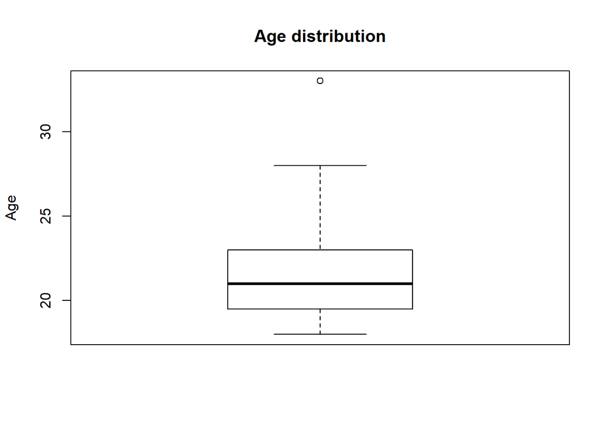

```r
boxplot(mydat$age, main = 'Age distribution', ylab = 'Age')
```

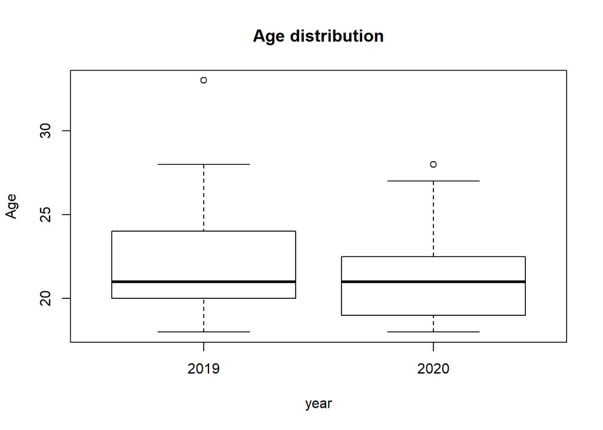

```r
boxplot(age~year,mydat, main = 'Age distribution', ylab = 'Age')
```

#### Exercise 15: There is a point lying outside of the box (see top quadrant). What does this indicate?

#### Exercise 16: Could you plot the descriptive of the `length` variable?

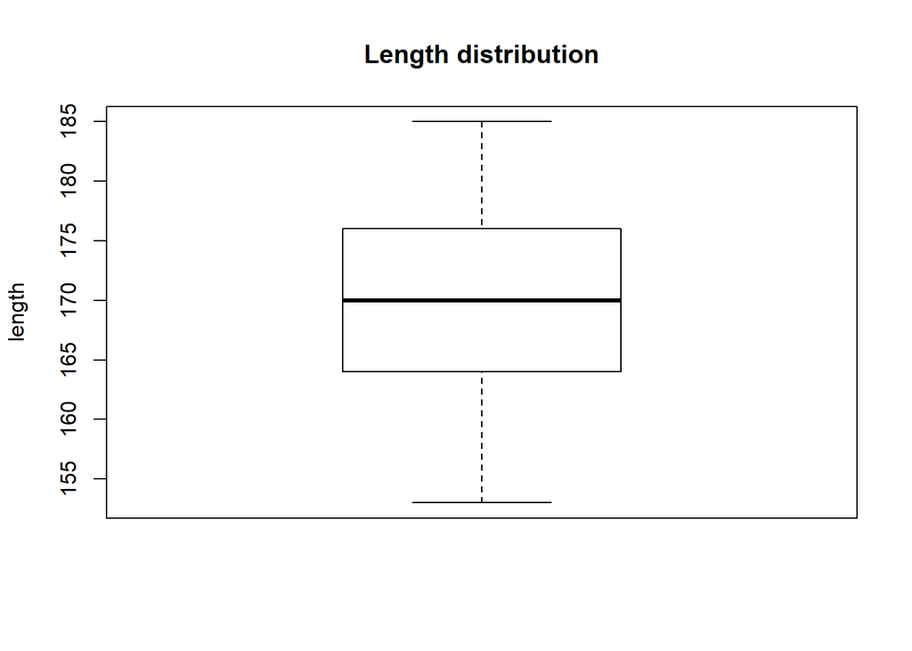

```r
boxplot(mydat$length, main = 'Length distribution', ylab = 'length')
```

#### Exercise 17: Now that you have explored both variables, age and length, how do they differ in terms of data distribution?

So far we only have learnt about the distribution of one variable. What if we portrait the `age` with the `favPet` variables in a boxplot?

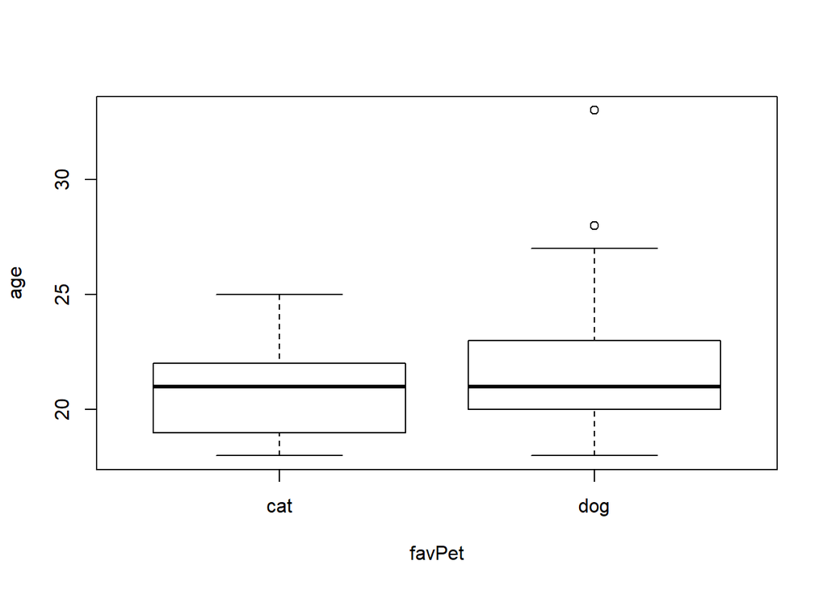

```r
boxplot(age ~ favPet, data = mydat)
```

```r
?boxplot
```

```
## starting httpd help server ... done
```

Let’s make it a little bit more funcy. It is just matter of colors!:

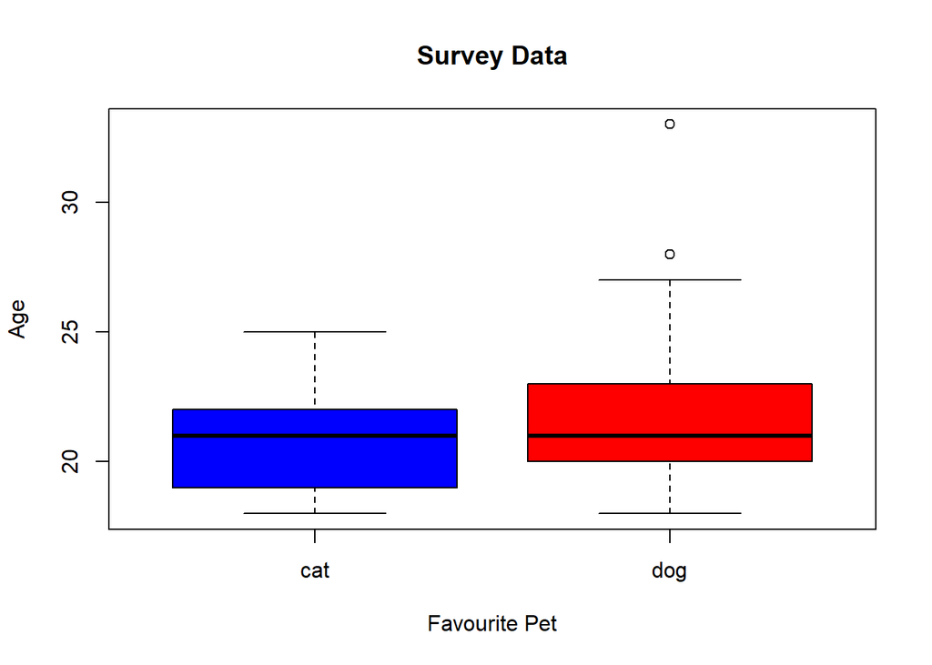

```r
boxplot(age ~ favPet, data = mydat, main = "Survey Data", xlab = "Favourite Pet", ylab="Age", col = (c('blue','red')))
```

#### Exercise 18: Which favourite pet did the oldest person choose in the dataset?

#### Exercise 19: As in the last graph, could you create another boxplot that shows the distribution of `favPet` responses and `lenght` variable?

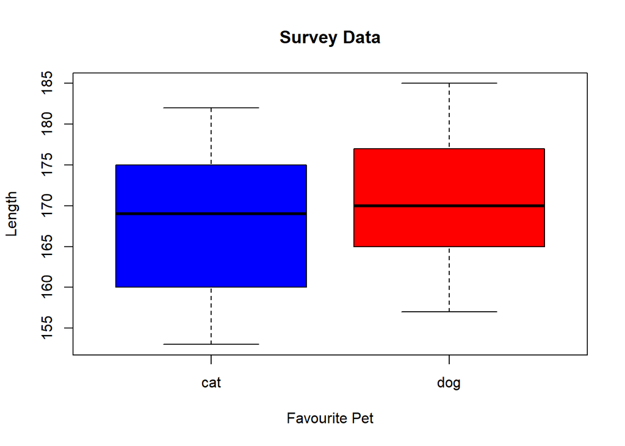

```r
boxplot(length ~ favPet, data = mydat, main = "Survey Data", xlab = "Favourite Pet", ylab="Length", col = (c('blue','red')))
```